# tf21147_EMATM0061_A_Report

Kahim Wong

11/11/2021

## A.1

Begin by downloading the csv file available within the Assessment section within Blackboard entitled “finance_data_EMATM0061”.

Next load the ““finance_data_EMATM0061” csv file into R data frame called “finance_data_original”.

How many rows and how many columns does this data frame have?

```r
library(tidyverse)
folder_path<-"./"
file_name<-"finance_data_EMATM0061.csv"
file_path<-paste(folder_path,file_name,sep="")

finance_data_original<-read.csv(file_path,fill = 1)
dim(finance_data_original)
```

```
## [1] 1051   30
```

The output of dim(finance_data_original) is 1051 30, therefore, there are 1051 rows and 30 columns.

## A.2

• The first column should be called “state_year_code” and correspond to the “state_year_code” column in the csv.

• The second column should be called “education_expenditure” and should correspond to the “Details.Education.Education.Total” column in the csv.

• The third column should be called “health_expenditure” and should correspond to the “Details.Health.Health.Total.Expenditure” column in the csv.

• The fourth column should be called “transport_expenditure” and should correspond to the “Details.Transportation.Highways.Highways.Total.Expenditure” column in the csv.

• The fifth column should be called “totals_revenue” and should correspond to the “Totals.Revenue” column in the csv.

• The sixth column should be called “totals_expenditure” and should correspond to the “Totals.Expenditure” column in the csv.

```r
finance_data<-finance_data_original%>%
  select(state_year_code, Details.Education.Education.Total, Details.Health.Health.Total.Expenditure, Details.Transportation.Highways.Highways.Total.Expenditure, Totals.Revenue, Totals.Expenditure)%>%
  rename(education_expenditure=Details.Education.Education.Total, health_expenditure=Details.Health.Health.Total.Expenditure, transport_expenditure=Details.Transportation.Highways.Highways.Total.Expenditure, totals_revenue=Totals.Revenue, totals_expenditure=Totals.Expenditure)
```

Display a subset of the “finance_data” dataframe consisting of the first five rows and first three columns (“state_year_code”,“education_expenditure”,“health_expenditure”).

```r
head(finance_data, c(5,3))
```

```
##   state_year_code education_expenditure health_expenditure
## 1   ALABAMA__1992               3570524                 NA
## 2   ALABAMA__1993               3663465                 NA
## 3   ALABAMA__1994               3969277             487044
## 4   ALABAMA__1995               4400912             491648
## 5   ALABAMA__1996               4872259             514380
```

## A.3

Create a new column within the “finance_data” data frame called “totals_saving” which is equal to the difference between revenue and the expenditure ie. the elements of the “totals_saving” column are equal to elements within the “totals_revenue” minus the element within the “totals_expenditure” coluumn, for each row.

```r
finance_data_A3<-finance_data%>%
  mutate(totals_savings=totals_revenue-totals_expenditure)
```

Your “finance_data” data frame should now have seven columns.

```r
dim(finance_data_A3)
```

```
## [1] 1051    7
```

Display a subset of the “finance_data” dataframe consisting of the first three rows and the four columns “state_year_code”,“totals_revenue”,“totals_expenditure”,“totals_savings”.

```r
finance_data_A3%>%
  select(state_year_code, totals_revenue, totals_expenditure, totals_savings)%>%
  head(3)
```

```
##   state_year_code totals_revenue totals_expenditure totals_savings
## 1   ALABAMA__1992       10536166            9650515         885651
## 2   ALABAMA__1993       11389335           10242374        1146961
## 3   ALABAMA__1994       11599362           10815221         784141
```

## A.4

The “state_year_code” column within your “finance_data” data frame contains both a state and a year in character format connected via a double underscore.

Divide the “state_year_code” column into two separate columns, a “state” column and a “year” column.

```r
finance_data_A4<-finance_data_A3%>%
  separate(state_year_code, into = c("state","year"), sep = "__", convert = 1)
```

```r
dim(finance_data_A4)
```

```
## [1] 1051    8
```

Convert the states so that they appear with the first letter of each word in upper case and the remainder in lower case eg. we should see “New Hampshire” rather than “NEW HAMPSHIRE”. You may wish to use the function str_to_title().

```r
finance_data_A4<-finance_data_A4%>%
  mutate(state=str_to_title(state))
```

Display a subset of the “finance_data” data frame consisting of the first three rows and the five columns “state”, “year”,“totals_revenue”,“totals_expenditure”,“totals_savings”.

```r
finance_data_A4%>%
  select(state, year, totals_revenue, totals_expenditure, totals_savings)%>%
  head(3)
```

```
##     state year totals_revenue totals_expenditure totals_savings
## 1 Alabama 1992       10536166            9650515         885651
## 2 Alabama 1993       11389335           10242374        1146961
## 3 Alabama 1994       11599362           10815221         784141
```

## A.5

Generate a plot which displays the total revenue (“total_revenue”) as function of the year (“year”) for the following four states: Louisiana, Montana, Mississippi and Kentucky.

Display the revenue in terms of millions of dollars.

```r
library(scales)
```

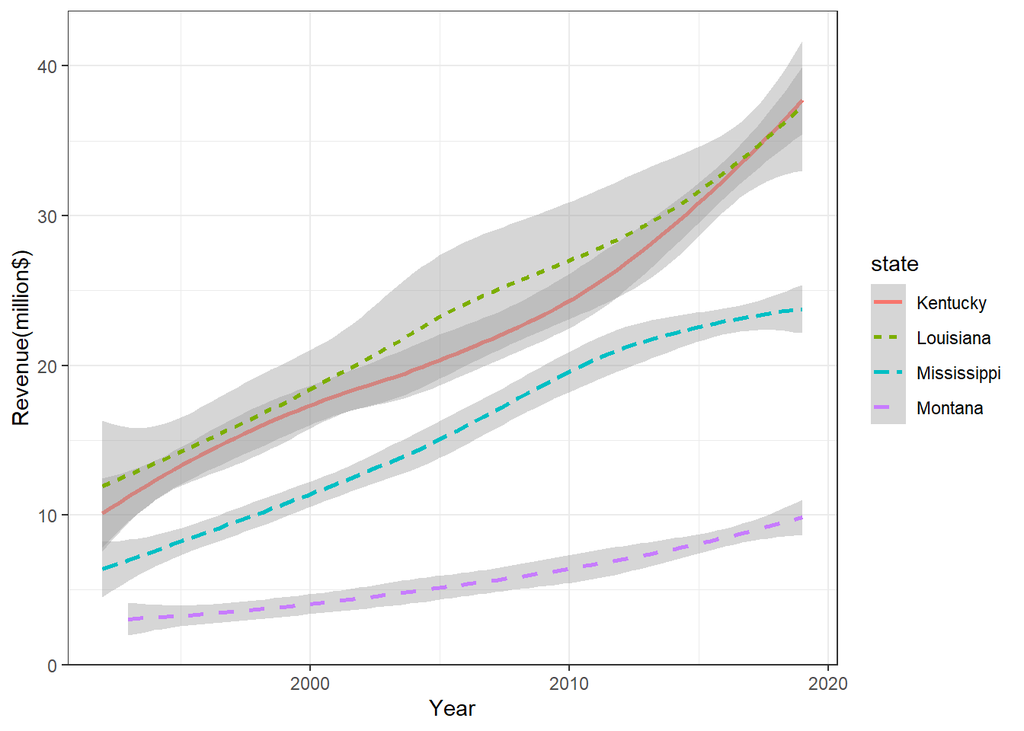

```r
finance_data_A4%>%
  filter(state=="Louisiana"|state=="Montana"|state=="Mississippi"|state=="Kentucky")%>%
  ggplot(aes(x=year, y=totals_revenue, color=state, linetype=state))+geom_smooth()+theme_bw()+labs(x="Year", y="Revenue(million$)")+scale_y_continuous(labels = function(x) x/1000000)
```

## A.6

```r
get_decade<-function(number){
  return(number-(number%%10))
}
```

Use your get_decade() function to add a new column to the “finance_data” data frame called “decade” which should give the decade corresponding to the year column. For example, the decade of the years 1990,1991,. . . ,1998,1999 is 1990.

```r
finance_data_A6<-finance_data_A4%>%
  mutate(decade=get_decade(year))
```

```r
dim(finance_data_A6)
```

```
## [1] 1051    9
```

Which three states had the highest mean-average savings (“totals_savings”) over the decade starting 2000?

```r
finance_data_A6%>%
  filter(decade==2000)%>%
  group_by(state)%>%
  summarise(mean_average_savings=mean(totals_savings, na.rm=1))%>%
  arrange(desc(mean_average_savings))%>%
  head(3)
```

```
## # A tibble: 3 x 2
##   state      mean_average_savings
##   <chr>                     <dbl>
## 1 Texas                  4103352.
## 2 Ohio                   3025980
## 3 California             2510483.
```

## A.7

Next generate a summary data frame from the “finance_data” data frame called “alaska_summary” with the following properties:

Your summary data frame should correspond to rows associated with the state of Alaska. Your summary dataframe should have three rows each corresponding to a decade from 1990 through to 2010 inclusive. Your dataframe should also have seven columns:

1. “decade” – the decade (1990, 2000, 2010)
2. “ed_mn” – the mean of the education expenditure in California for the corresponding decade
3. “ed_md” – the median of the education expenditure in California for the corresponding decade
4. “he_mn” – the mean of the health expenditure in California for the corresponding decade
5. “he_md” – the median of the health expenditure in California for the corresponding decade
6. “tr_mn” – the mean of the transport expenditure in California for the corresponding decade
7. “tr_md” – the median of the transport expenditure in California for the corresponding decade

You should use Tidyverse methods to create your “alaska_summary” data frame.

```r
alaska_summary<-finance_data_A6%>%
  filter(state=="Alaska" & (decade==1990|decade==2000|decade==2010))%>%
  group_by(decade)%>%
  summarise(ed_mn=mean(education_expenditure, na.rm=1),
            ed_md=median(education_expenditure, na.rm=1),
            he_mn=mean(health_expenditure, na.rm=1),
            he_md=median(health_expenditure, na.rm=1),
            tr_mn=mean(transport_expenditure, na.rm=1),
            tr_md=median(transport_expenditure, na.rm=1))
```

Display the “alaska_summary” data frame.

```r
alaska_summary
```

```
## # A tibble: 3 x 7
##   decade    ed_mn    ed_md   he_mn   he_md    tr_mn    tr_md
##    <dbl>    <dbl>    <dbl>   <dbl>   <dbl>    <dbl>    <dbl>
## 1   1990 1246426. 1246864. 162785. 164546.  582137.  582710.
## 2   2000 1546233. 1566815  152003. 160168   723347.  687407
## 3   2010 2642603. 2595207  274688  278394  1210822. 1271514
```

## A.8

Create a function called impute_by_median which takes as input a vector numerical values, which may include some “NA”s, and replaces any missing values (“NA”s) with the median over the vector.

```r
impute_by_median<-function(x){
  mu<-median(x,na.rm=1) # first compute the mean of x
  impute_f<-function(z){ # coordinate-wise imputation
    if(is.na(z)){
      return(mu) # if z is na replace with mean
    }else{
      return(z) # otherwise leave in place
    }
  }
  return(map_dbl(x,impute_f)) # apply the map function to impute across vector
}
```

Next generate a subset of your “finance_data” data frame called “idaho_2000” which contains all those rows in which the state column takes the value “Idaho” and the “decade” column takes the value “2000” and includes the columns “year”, “education_expenditure”, “health_expenditure”, “transport_expenditure”, “totals_revenue”, “totals_expenditure”, “totals_savings” (i.e. all columns except “state” and “decade”).

```r
idaho_2000<-finance_data_A6%>%
  filter(state=="Idaho" & decade==2000)%>%
  select(-state, -decade)
```

Now apply your “impute_by_median” data frame to create a new data frame called “idaho_2000_imputed” which is based on your existing “idaho_2000” data frame but with any missing values replaced with the corresponding median value for the that column. That is, for each of the columns “education_expenditure”, “health_expenditure”, “transport_expenditure”, “totals_revenue”, “totals_expenditure”, “totals_savings” any missing values (given by “NA”) are replaced with the median over that column.

```r
idaho_2000_imputed<-idaho_2000%>%
  mutate_all(impute_by_median)
```

Display a subset of your “idaho_2000_imputed” data frame consisting of the first five rows and the four columns “year”, “health_expenditure”, “education_expenditure” and “totals_savings”.

```r
idaho_2000_imputed%>%
  select("year", "health_expenditure", "education_expenditure", "totals_savings")%>%
  head(5)
```

```
##   year health_expenditure education_expenditure totals_savings
## 1 2000            98510.0               1663980        1083732
## 2 2001           103705.0               1768837         334438
## 3 2002           109896.5               1768837        -746375
## 4 2003           116088.0               1886421         709085
## 5 2004           131165.0               1768837        1349740
```